# EE4708: Data Analytics Laboratory

## Assignment 1: Linear Regression

## Submitted by: Gautham Govind A, EE19B022

### Importing the necessary packages

```python
import numpy as np                                 # Numpy for mathematical manipulations
import pandas as pd                                # Pandas for data handling and manipulation
from sklearn.linear_model import LinearRegression  # Scikit learn for performing linear regression
from sklearn.metrics import mean_squared_error     # Scikit learn for mean square error calculation
from sklearn.metrics import r2_score               # Scikit learn for R2 score calculation

import re                                          # Regular expressions for string searching

import matplotlib.pyplot as plt                    # Matplotlib for plotting
import seaborn as sns                              # Seaborn for plotting
```

```python
plt.rcParams.update({'font.size': 13})
```

### Reading in the data

Data is stored in a .xlsx file. For ease of processing, the file will be read in as a "Dataframe" using the Pandas library. This enables us to make use of the multitude of functions provided by the Pandas library.

It is assumed that the dataset is located in the same directory as this ipynb file.

```python
# Openpyxl is a required package for pandas to open excel files.

!pip install openpyxl
```

```python
#The first column of the given excel file can be used as the index column

df = pd.read_excel("merged_data.xlsx", index_col = 0)
```

### Data preprocessing and cleaning

Basic information regarding data:

```python
df.info()
```

```
<class 'pandas.core.frame.DataFrame'>
Int64Index: 3134 entries, 0 to 3133
Data columns (total 25 columns):
 #   Column             Non-Null Count  Dtype
---  ------             --------------  -----
 0   State              3134 non-null   object
 1   AreaName           3134 non-null   object
 2   All_Poverty        3134 non-null   int64
 3   M_Poverty          3134 non-null   int64
 4   F_Poverty          3134 non-null   int64
 5   FIPS               3134 non-null   int64
 6   Med_Income         3133 non-null   float64
 7   Med_Income_White   3132 non-null   float64
 8   Med_Income_Black   1924 non-null   float64
 9   Med_Income_Nat_Am  1474 non-null   float64
```

[output cut: 17 more lines]

The task at hand is to examine the effect of socioeconomic status on cancer incidence and mortality at a **national level** . Hence, the particular state/county from which a particular datapoint is obtained is not of relevance to us.

We can therefore safely discard columns "State", "AreaName", "FIPS", "fips_x" and "fips_y".

```python
df = df.drop(columns = ["State", "AreaName", "FIPS", "fips_x", "fips_y"])
```

Next, we observe that the incidence rate, avg annual incidence, mortality rate and avg annuual deaths are all marked as having "object" dataype. This is an indication that not all values in these columns are numerical. This will present a problem during mathematical analyses. Hence, it is essential to examine these columns and try to make all values numerical or categorical.

Let's check the unique values which appear on the column "Incidence_Rate":

```python
df['Incidence_Rate'].unique()
```

```
array(['*', 61.5, 62.7, 58.1, 35.1, 64.9, 88.3, 74.7, 69.7, 103.6, 153.4,
       67.6, 44, 76.8, 66.1, 58.3, 74.9, 66.9, 74.6, 86.4, 65.8, 84.2,
       75.4, 82.4, 73.9, 49.2, 69.5, 83.3, 71.5, 75.9, 73.5, 82.6, 83,
       69.6, 76.7, 76.2, 60.8, 78.1, 75.5, 81.9, 77.3, 72.4, 90.3, 87.9,
       71, 66.5, 70.8, 80.9, 65.1, 80.4, 69.3, 88.1, 59.4, 73.4, 57.6,
       57.9, 64.8, 61.6, 74.2, 79.4, 62.3, 61, 83.1, 65.6, 61.8, 78.7,
       57.1, 55.5, 74, 70.5, 72.3, 98.3, 74.8, 73.2, 90.8, 85.9, 77, 85.6,
       56.4, 67.7, 86.3, 82.5, 59.1, 76.4, 71.6, 108.7, 83.6, 77.5, 72,
       75, 79.1, 75.6, 82.2, 79.2, 77.1, 64.7, 80.6, 96.1, 89.2, 60.6,
       94.2, 96.2, 82.3, 55.9, 104.4, 97.5, 97.2, 98.1, 102.7, 57, 63.4,
       79.5, 87, 91.9, 67.8, 82.7, 81.2, 73.6, 89.5, 67.5, 69.2, 63.9, 84,
       98.8, 87.8, 114, 67.1, 89, 68, 83.9, 65.2, 91.5, 72.1, 78.2, 70.4,
       89.3, 91.2, 108.5, 22.9, 46.9, 36.7, 54.3, 45.5, 64, 54.4, 52.2,
       76.6, 39.6, 50.9, 36.1, 51.9, 48, 46, 58.7, 61.4, 52.3, 56, 78.4,
       50, 50.8, 61.2, 44.3, 45.7, 55.7, 48.8, 73.7, 60.9, 39.9, 51.8,
       41.6, 54.6, 56.9, 43.7, 24.6, 42.6, 53.3, 47.3, 44.1, 49.6, 44.2,
       47.2, 40.2, 49.5, 49, 56.8, 45.3, 42.1, 41.1, 37.6, 62.5, 60.5,
       57.4, 56.3, 66.6, 47.9, 58, 41.5, 42.3, 68.1, 52.6, 47.5, 31.7,
       35.5, 48.4, 36.9, 38.1, 34.7, 59.5, 46.3, 48.5, 37.1, 28.3, 50.3,
       43.2, 24.8, 59.2, 55.1, 34.4, 39.7, 53.5, 36.4, 56.1, 40, 40.5,
       35.8, 53, 24.1, 67.3, 49.8, 29.2, 31.5, 14.8, 54.9, 62, 65.7, 70.2,
       68.7, 65, 59, 99.5, 88.4, 82.1, 79.7, 43.3, 88.2, 57.7, 100, 93.4,
       66.4, 74.3, 92.6, 69, 73.3, 71.2, 67, 42.5, 97.3, 76, 54.8, 103.5,
       82, 59.6, 44.4, 71.8, 93.3, 54.7, 54.1, 68.9, 74.4, 64.5, 54.2,
       65.3, 87.2, 84.4, 203.7, 95.9, 87.5, 72.9, 89.6, 91.3, 76.9, 84.3,
       78.6, 95.7, 67.4, 82.9, 60, 101.5, 64.1, 86.9, 60.3, 90, 100.7,
       74.1, 53.2, 81.3, 58.6, 81.1, 85.2, 68.8, 47.4, 81.4, 54.5, 76.1,
       71.9, 94.7, 69.9, 64.4, 38.8, 94.4, 104.6, 83.4, 62.8, 68.6, 65.4,
       79.9, 86.5, 77.2, 83.2, 88.9, 55, 90.4, 64.6, 66.8, 89.1, 85.1,
       72.7, 71.7, 65.5, 103.1, 70.3, 78.9, 46.8, 77.7, 77.9, 80.1, 102,
       50.6, 110.8, 56.6, 60.7, 63.1, 100.8, 63, 74.5, 71.4, 62.4, 78.5,
       71.1, 91.8, 67.9, 70.6, 84.9, 68.2, 69.8, 77.6, 66, 44.9, 48.3,
       45.2, 42.4, 72.5, 61.3, 82.8, 40.9, 45.4, 47.6, 52.9, 57.8, 53.6,
       38.4, 86.7, 59.9, 63.7, 48.7, 55.6, 58.8, 58.5, 41.9, 50.5, 60.1,
       58.2, 73.1, 48.2, 52.1, 98, 61.1, 52.4, 75.3, 84.6, 43.4, 46.1,
       43.1, 36, 41, 79, 38.7, 22.6, 35.7, 34, 55.4, 40.4, 33.9, 46.5,
       40.7, 41.4, 98.7, 53.4, 41.3, 68.3, 93.5, 66.3, 54, 89.7, 94.1,
       63.6, 72.8, 94.3, 88.7, 103.4, 92.7, 58.9, 69.1, 81.6, 90.7, 96.6,
       83.5, 92.3, 100.9, 66.7, 79.8, 68.4, 105.5, 113.1, 75.8, 63.8,
       91.6, 50.2, 61.9, 77.8, 73.8, 94.6, 68.5, 87.4, 79.3, 83.8, 70,
```

[output cut: 24 more lines]

```
       86.2, 78, 49.9, 95.6, 62.9, 106, 55.8, 90.6, 114.7, 95.3, 52, 58.4,
       97.1, 42.8, 85.3, 48.9, 62.1, 71.3, 66.2, 81, 96.9, 73, 56.5, 57.5,
       85.7, 84.5, 95.5, 51.4, 59.7, 43.5, 42.7, 56.7, 40.6, 53.9, 49.3,
       32.5, 45.9, 43.8, 63.3, 48.1, 59.3, 57.3, 42.2, 29.3, 36.8, 72.6,
       53.8, 39.4, 41.2, 44.7, 26.5, 13.5, 34.8, 55.2, 37.3, 47.8, 35,
       '__', 50.4, 61.7, 89.8, 72.2, 87.1, 106.2, 86.6, 65.9, 55.3, 70.7,
       69.4, 48.6, 56.2, 114.2, 80.2, 60.2, 88.5, 62.2, 51.3, 63.2, 53.1,
       43.9, 45.6, 62.6, 47, 51, 81.5, 96, 49.4, 38.6, 45, 46.4, 104.7,
       105.9, 96.8, 99.2, 102.8, 88, 100.4, 102.9, 83.7, 98.6, 63.5, 98.2,
       93.8, 116, 109.2, 101.4, 45.1, 44.5, 50.7, 32.2, 32.9, 39.2, 32.7,
       51.7, 42, 99.4, 38.5, 49.7, 44.8, 30.3, 38.2, 20.4, 15.8, 25, 29.5,
       32.6, 25.8, 32.1, 18.2, 27.6, 18.5, 34.5, 29.7, 33.6, 91.1, 37.2,
       57.2, 40.8, 51.2, 32, 28.8, 107.3, 167, 110.1, 100.5, 127.9, 37,
       47.7, 41.7, 51.5, 99.8, 111.5, 115.7, 78.8, 41.8, 46.2, 36.3, 23.7],
      dtype=object)
```

It can be seen that there are 3 categories of non-numerical values:

- '*' : this indicates that the incidence rate is very low
- strings ending with # : these are probably just numerical values with the # introduced as a noise. These datapoints can be used after removing the #
- '_ ' and '__ ' : this probably indicates that the data is unavailable

We will first deal with the case where data is unavailable:

```python
df[(df['Incidence_Rate'] == '__') | (df['Incidence_Rate'] == '_')]
```

|  | All_Poverty | M_Poverty | F_Poverty | Med_Income | Med_Income_White | Med_Income_Black | Med_Income_Nat_Am | Med_Income_Asian | Hispanic | M_With | M_Without | F_With | F_Without | All_With | All_Without | Incidence_Rate | Avg_Ann_Incidence | recent_trend | Mortality_Rate | Avg_Ann_Deaths |
| --- | --- | --- | --- | --- | --- | --- | --- | --- | --- | --- | --- | --- | --- | --- | --- | --- | --- | --- | --- | --- |
| 882 | 2257 | 957 | 1300 | 38698.0 | 39505.0 | 38482.0 | 20833.0 | NaN | 39500.0 | 5602 | 779 | 5754 | 741 | 11356 | 1520 | _ | _ | _ | 52.2 | 10 |
| 883 | 1362 | 668 | 694 | 40696.0 | 40370.0 | NaN | 81200.0 | NaN | NaN | 3391 | 487 | 3407 | 509 | 6798 | 996 | _ | _ | _ | 50.6 | 6 |
| 884 | 2970 | 1310 | 1660 | 43581.0 | 44353.0 | 22375.0 | NaN | NaN | NaN | 6755 | 1145 | 7594 | 963 | 14349 | 2108 | _ | _ | _ | 51.1 | 10 |
| 885 | 511 | 245 | 266 | 51811.0 | 51658.0 | NaN | NaN | NaN | 65938.0 | 2170 | 220 | 2078 | 261 | 4248 | 481 | _ | _ | _ | 56 | 4 |
| 886 | 4261 | 1840 | 2421 | 44013.0 | 45325.0 | 22326.0 | 18958.0 | NaN | 22247.0 | 11051 | 2075 | 12159 | 1703 | 23210 | 3778 | _ | _ | _ | 45.5 | 17 |
| ... | ... | ... | ... | ... | ... | ... | ... | ... | ... | ... | ... | ... | ... | ... | ... | ... | ... | ... | ... | ... |
| 1970 | 832 | 350 | 482 | 45230.0 | 46528.0 | NaN | NaN | NaN | 41071.0 | 1995 | 525 | 1846 | 413 | 3841 | 938 | __ | __ | __ | 61 | 4 |
| 1971 | 293 | 134 | 159 | 64832.0 | 66161.0 | NaN | 18438.0 | NaN | NaN | 1493 | 376 | 1826 | 210 | 3319 | 586 | __ | __ | __ | * | * |
| 1972 | 65248 | 30454 | 34794 | 52870.0 | 54480.0 | 30773.0 | 42183.0 | 56760.0 | 41422.0 | 176960 | 39625 | 183055 | 32403 | 360015 | 72028 | __ | __ | __ | 41.7 | 182 |
| 1973 | 987 | 381 | 606 | 57122.0 | 58096.0 | NaN | 52548.0 | NaN | 68333.0 | 3873 | 526 | 3532 | 731 | 7405 | 1257 | __ | __ | __ | 46.1 | 6 |
| 1974 | 8787 | 3992 | 4795 | 47668.0 | 47882.0 | 93036.0 | 30708.0 | 74458.0 | 43972.0 | 21461 | 4907 | 22411 | 3802 | 43872 | 8709 | __ | __ | __ | 51.8 | 39 |

209 rows × 20 columns

```python
df[(df['Incidence_Rate'] == '__') | (df['Incidence_Rate'] == '_')].shape
```

```
(209, 20)
```

Only 209/3134 entires lack incidence data. Since this is just 6%, we can just drop these columns.

```python
df = df.drop(df[(df['Incidence_Rate'] == '__') | (df['Incidence_Rate'] == '_')].index)
```

```python
df['Incidence_Rate'].unique()
```

```
array(['*', 61.5, 62.7, 58.1, 35.1, 64.9, 88.3, 74.7, 69.7, 103.6, 153.4,
       67.6, 44, 76.8, 66.1, 58.3, 74.9, 66.9, 74.6, 86.4, 65.8, 84.2,
       75.4, 82.4, 73.9, 49.2, 69.5, 83.3, 71.5, 75.9, 73.5, 82.6, 83,
       69.6, 76.7, 76.2, 60.8, 78.1, 75.5, 81.9, 77.3, 72.4, 90.3, 87.9,
       71, 66.5, 70.8, 80.9, 65.1, 80.4, 69.3, 88.1, 59.4, 73.4, 57.6,
       57.9, 64.8, 61.6, 74.2, 79.4, 62.3, 61, 83.1, 65.6, 61.8, 78.7,
       57.1, 55.5, 74, 70.5, 72.3, 98.3, 74.8, 73.2, 90.8, 85.9, 77, 85.6,
       56.4, 67.7, 86.3, 82.5, 59.1, 76.4, 71.6, 108.7, 83.6, 77.5, 72,
       75, 79.1, 75.6, 82.2, 79.2, 77.1, 64.7, 80.6, 96.1, 89.2, 60.6,
       94.2, 96.2, 82.3, 55.9, 104.4, 97.5, 97.2, 98.1, 102.7, 57, 63.4,
       79.5, 87, 91.9, 67.8, 82.7, 81.2, 73.6, 89.5, 67.5, 69.2, 63.9, 84,
       98.8, 87.8, 114, 67.1, 89, 68, 83.9, 65.2, 91.5, 72.1, 78.2, 70.4,
       89.3, 91.2, 108.5, 22.9, 46.9, 36.7, 54.3, 45.5, 64, 54.4, 52.2,
       76.6, 39.6, 50.9, 36.1, 51.9, 48, 46, 58.7, 61.4, 52.3, 56, 78.4,
       50, 50.8, 61.2, 44.3, 45.7, 55.7, 48.8, 73.7, 60.9, 39.9, 51.8,
       41.6, 54.6, 56.9, 43.7, 24.6, 42.6, 53.3, 47.3, 44.1, 49.6, 44.2,
       47.2, 40.2, 49.5, 49, 56.8, 45.3, 42.1, 41.1, 37.6, 62.5, 60.5,
       57.4, 56.3, 66.6, 47.9, 58, 41.5, 42.3, 68.1, 52.6, 47.5, 31.7,
       35.5, 48.4, 36.9, 38.1, 34.7, 59.5, 46.3, 48.5, 37.1, 28.3, 50.3,
       43.2, 24.8, 59.2, 55.1, 34.4, 39.7, 53.5, 36.4, 56.1, 40, 40.5,
       35.8, 53, 24.1, 67.3, 49.8, 29.2, 31.5, 14.8, 54.9, 62, 65.7, 70.2,
       68.7, 65, 59, 99.5, 88.4, 82.1, 79.7, 43.3, 88.2, 57.7, 100, 93.4,
       66.4, 74.3, 92.6, 69, 73.3, 71.2, 67, 42.5, 97.3, 76, 54.8, 103.5,
       82, 59.6, 44.4, 71.8, 93.3, 54.7, 54.1, 68.9, 74.4, 64.5, 54.2,
       65.3, 87.2, 84.4, 203.7, 95.9, 87.5, 72.9, 89.6, 91.3, 76.9, 84.3,
       78.6, 95.7, 67.4, 82.9, 60, 101.5, 64.1, 86.9, 60.3, 90, 100.7,
       74.1, 53.2, 81.3, 58.6, 81.1, 85.2, 68.8, 47.4, 81.4, 54.5, 76.1,
       71.9, 94.7, 69.9, 64.4, 38.8, 94.4, 104.6, 83.4, 62.8, 68.6, 65.4,
       79.9, 86.5, 77.2, 83.2, 88.9, 55, 90.4, 64.6, 66.8, 89.1, 85.1,
       72.7, 71.7, 65.5, 103.1, 70.3, 78.9, 46.8, 77.7, 77.9, 80.1, 102,
       50.6, 110.8, 56.6, 60.7, 63.1, 100.8, 63, 74.5, 71.4, 62.4, 78.5,
       71.1, 91.8, 67.9, 70.6, 84.9, 68.2, 69.8, 77.6, 66, 44.9, 48.3,
       45.2, 42.4, 72.5, 61.3, 82.8, 40.9, 45.4, 47.6, 52.9, 57.8, 53.6,
       38.4, 86.7, 59.9, 63.7, 48.7, 55.6, 58.8, 58.5, 41.9, 50.5, 60.1,
       58.2, 73.1, 48.2, 52.1, 98, 61.1, 52.4, 75.3, 84.6, 43.4, 46.1,
       43.1, 36, 41, 79, 38.7, 22.6, 35.7, 34, 55.4, 40.4, 33.9, 46.5,
       40.7, 41.4, 98.7, 53.4, 41.3, 68.3, 93.5, 66.3, 54, 89.7, 94.1,
       63.6, 72.8, 94.3, 88.7, 103.4, 92.7, 58.9, 69.1, 81.6, 90.7, 96.6,
       83.5, 92.3, 100.9, 66.7, 79.8, 68.4, 105.5, 113.1, 75.8, 63.8,
       91.6, 50.2, 61.9, 77.8, 73.8, 94.6, 68.5, 87.4, 79.3, 83.8, 70,
```

[output cut: 24 more lines]

```
       86.2, 78, 49.9, 95.6, 62.9, 106, 55.8, 90.6, 114.7, 95.3, 52, 58.4,
       97.1, 42.8, 85.3, 48.9, 62.1, 71.3, 66.2, 81, 96.9, 73, 56.5, 57.5,
       85.7, 84.5, 95.5, 51.4, 59.7, 43.5, 42.7, 56.7, 40.6, 53.9, 49.3,
       32.5, 45.9, 43.8, 63.3, 48.1, 59.3, 57.3, 42.2, 29.3, 36.8, 72.6,
       53.8, 39.4, 41.2, 44.7, 26.5, 13.5, 34.8, 55.2, 37.3, 47.8, 35,
       50.4, 61.7, 89.8, 72.2, 87.1, 106.2, 86.6, 65.9, 55.3, 70.7, 69.4,
       48.6, 56.2, 114.2, 80.2, 60.2, 88.5, 62.2, 51.3, 63.2, 53.1, 43.9,
       45.6, 62.6, 47, 51, 81.5, 96, 49.4, 38.6, 45, 46.4, 104.7, 105.9,
       96.8, 99.2, 102.8, 88, 100.4, 102.9, 83.7, 98.6, 63.5, 98.2, 93.8,
       116, 109.2, 101.4, 45.1, 44.5, 50.7, 32.2, 32.9, 39.2, 32.7, 51.7,
       42, 99.4, 38.5, 49.7, 44.8, 30.3, 38.2, 20.4, 15.8, 25, 29.5, 32.6,
       25.8, 32.1, 18.2, 27.6, 18.5, 34.5, 29.7, 33.6, 91.1, 37.2, 57.2,
       40.8, 51.2, 32, 28.8, 107.3, 167, 110.1, 100.5, 127.9, 37, 47.7,
       41.7, 51.5, 99.8, 111.5, 115.7, 78.8, 41.8, 46.2, 36.3, 23.7],
      dtype=object)
```

Next, we deal with values ending with #.

```python
hash_indices = np.array(df[df.Incidence_Rate.str.contains("#$", na = False)].index)
```

```python
df.loc[hash_indices, 'Incidence_Rate'] = df.loc[hash_indices, 'Incidence_Rate'].str[:-2]
```

```python
df['Incidence_Rate'].unique()
```

```
array(['*', 61.5, 62.7, 58.1, 35.1, 64.9, 88.3, 74.7, 69.7, 103.6, 153.4,
       67.6, 44, 76.8, 66.1, 58.3, 74.9, 66.9, 74.6, 86.4, 65.8, 84.2,
       75.4, 82.4, 73.9, 49.2, 69.5, 83.3, 71.5, 75.9, 73.5, 82.6, 83,
       69.6, 76.7, 76.2, 60.8, 78.1, 75.5, 81.9, 77.3, 72.4, 90.3, 87.9,
       71, 66.5, 70.8, 80.9, 65.1, 80.4, 69.3, 88.1, 59.4, 73.4, 57.6,
       57.9, 64.8, 61.6, 74.2, 79.4, 62.3, 61, 83.1, 65.6, 61.8, 78.7,
       57.1, 55.5, 74, 70.5, 72.3, 98.3, 74.8, 73.2, 90.8, 85.9, 77, 85.6,
       56.4, 67.7, 86.3, 82.5, 59.1, 76.4, 71.6, 108.7, 83.6, 77.5, 72,
       75, 79.1, 75.6, 82.2, 79.2, 77.1, 64.7, 80.6, 96.1, 89.2, 60.6,
       94.2, 96.2, 82.3, 55.9, 104.4, 97.5, 97.2, 98.1, 102.7, 57, 63.4,
       79.5, 87, 91.9, 67.8, 82.7, 81.2, 73.6, 89.5, 67.5, 69.2, 63.9, 84,
       98.8, 87.8, 114, 67.1, 89, 68, 83.9, 65.2, 91.5, 72.1, 78.2, 70.4,
       89.3, 91.2, 108.5, 22.9, 46.9, 36.7, 54.3, 45.5, 64, 54.4, 52.2,
       76.6, 39.6, 50.9, 36.1, 51.9, 48, 46, 58.7, 61.4, 52.3, 56, 78.4,
       50, 50.8, 61.2, 44.3, 45.7, 55.7, 48.8, 73.7, 60.9, 39.9, 51.8,
       41.6, 54.6, 56.9, 43.7, 24.6, 42.6, 53.3, 47.3, 44.1, 49.6, 44.2,
       47.2, 40.2, 49.5, 49, 56.8, 45.3, 42.1, 41.1, 37.6, 62.5, 60.5,
       57.4, 56.3, 66.6, 47.9, 58, 41.5, 42.3, 68.1, 52.6, 47.5, 31.7,
       35.5, 48.4, 36.9, 38.1, 34.7, 59.5, 46.3, 48.5, 37.1, 28.3, 50.3,
       43.2, 24.8, 59.2, 55.1, 34.4, 39.7, 53.5, 36.4, 56.1, 40, 40.5,
       35.8, 53, 24.1, 67.3, 49.8, 29.2, 31.5, 14.8, 54.9, 62, 65.7, 70.2,
       68.7, 65, 59, 99.5, 88.4, 82.1, 79.7, 43.3, 88.2, 57.7, 100, 93.4,
       66.4, 74.3, 92.6, 69, 73.3, 71.2, 67, 42.5, 97.3, 76, 54.8, 103.5,
       82, 59.6, 44.4, 71.8, 93.3, 54.7, 54.1, 68.9, 74.4, 64.5, 54.2,
       65.3, 87.2, 84.4, 203.7, 95.9, 87.5, 72.9, 89.6, 91.3, 76.9, 84.3,
       78.6, 95.7, 67.4, 82.9, 60, 101.5, 64.1, 86.9, 60.3, 90, 100.7,
       74.1, 53.2, 81.3, 58.6, 81.1, 85.2, 68.8, 47.4, 81.4, 54.5, 76.1,
       71.9, 94.7, 69.9, 64.4, 38.8, 94.4, 104.6, 83.4, 62.8, 68.6, 65.4,
       79.9, 86.5, 77.2, 83.2, 88.9, 55, 90.4, 64.6, 66.8, 89.1, 85.1,
       72.7, 71.7, 65.5, 103.1, 70.3, 78.9, 46.8, 77.7, 77.9, 80.1, 102,
       50.6, 110.8, 56.6, 60.7, 63.1, 100.8, 63, 74.5, 71.4, 62.4, 78.5,
       71.1, 91.8, 67.9, 70.6, 84.9, 68.2, 69.8, 77.6, 66, 44.9, 48.3,
       45.2, 42.4, 72.5, 61.3, 82.8, 40.9, 45.4, 47.6, 52.9, 57.8, 53.6,
       38.4, 86.7, 59.9, 63.7, 48.7, 55.6, 58.8, 58.5, 41.9, 50.5, 60.1,
       58.2, 73.1, 48.2, 52.1, 98, 61.1, 52.4, 75.3, 84.6, 43.4, 46.1,
       43.1, 36, 41, 79, 38.7, 22.6, 35.7, 34, 55.4, 40.4, 33.9, 46.5,
       40.7, 41.4, 98.7, 53.4, 41.3, 68.3, 93.5, 66.3, 54, 89.7, 94.1,
       63.6, 72.8, 94.3, 88.7, 103.4, 92.7, 58.9, 69.1, 81.6, 90.7, 96.6,
       83.5, 92.3, 100.9, 66.7, 79.8, 68.4, 105.5, 113.1, 75.8, 63.8,
       91.6, 50.2, 61.9, 77.8, 73.8, 94.6, 68.5, 87.4, 79.3, 83.8, 70,
```

[output cut: 22 more lines]

```
       49.9, 95.6, 62.9, 106, 55.8, 90.6, 114.7, 95.3, 52, 58.4, 97.1,
       42.8, 85.3, 48.9, 62.1, 71.3, 66.2, 81, 96.9, 73, 56.5, 57.5, 85.7,
       84.5, 95.5, 51.4, 59.7, 43.5, 42.7, 56.7, 40.6, 53.9, 49.3, 32.5,
       45.9, 43.8, 63.3, 48.1, 59.3, 57.3, 42.2, 29.3, 36.8, 72.6, 53.8,
       39.4, 41.2, 44.7, 26.5, 13.5, 34.8, 55.2, 37.3, 47.8, 35, 50.4,
       61.7, 89.8, 72.2, 87.1, 106.2, 86.6, 65.9, 55.3, 70.7, 69.4, 48.6,
       56.2, 114.2, 80.2, 60.2, 88.5, 62.2, 51.3, 63.2, 53.1, 43.9, 45.6,
       62.6, 47, 51, 81.5, 96, 49.4, 38.6, 45, 46.4, 104.7, 105.9, 96.8,
       99.2, 102.8, 88, 100.4, 102.9, 83.7, 98.6, 63.5, 98.2, 93.8, 116,
       109.2, 101.4, 45.1, 44.5, 50.7, 32.2, 32.9, 39.2, 32.7, 51.7, 42,
       99.4, 38.5, 49.7, 44.8, 30.3, 38.2, 20.4, 15.8, 25, 29.5, 32.6,
       25.8, 32.1, 18.2, 27.6, 18.5, 34.5, 29.7, 33.6, 91.1, 37.2, 57.2,
       40.8, 51.2, 32, 28.8, 107.3, 167, 110.1, 100.5, 127.9, 37, 47.7,
       41.7, 51.5, 99.8, 111.5, 115.7, 78.8, 41.8, 46.2, 36.3, 23.7],
      dtype=object)
```

Finally, we deal with *.

```python
star_indices = df[df['Incidence_Rate'] == '*' ].index
```

```python
star_indices
```

```
Int64Index([   0,    1,    4,    5,    6,    8,   13,   21,  181,  225,
            ...
            2784, 2785, 2786, 2788, 2797, 2842, 2913, 2956, 3124, 3128],
           dtype='int64', length=211)
```

```python
df = df.drop(star_indices)
```

```python
#df.loc[star_indices, 'Incidence_Rate'] = 0
```

```python
#df.loc[star_indices]
```

```python
df['Incidence_Rate'].unique()
```

```
array([61.5, 62.7, 58.1, 35.1, 64.9, 88.3, 74.7, 69.7, 103.6, 153.4, 67.6,
       44, 76.8, 66.1, 58.3, 74.9, 66.9, 74.6, 86.4, 65.8, 84.2, 75.4,
       82.4, 73.9, 49.2, 69.5, 83.3, 71.5, 75.9, 73.5, 82.6, 83, 69.6,
       76.7, 76.2, 60.8, 78.1, 75.5, 81.9, 77.3, 72.4, 90.3, 87.9, 71,
       66.5, 70.8, 80.9, 65.1, 80.4, 69.3, 88.1, 59.4, 73.4, 57.6, 57.9,
       64.8, 61.6, 74.2, 79.4, 62.3, 61, 83.1, 65.6, 61.8, 78.7, 57.1,
       55.5, 74, 70.5, 72.3, 98.3, 74.8, 73.2, 90.8, 85.9, 77, 85.6, 56.4,
       67.7, 86.3, 82.5, 59.1, 76.4, 71.6, 108.7, 83.6, 77.5, 72, 75,
       79.1, 75.6, 82.2, 79.2, 77.1, 64.7, 80.6, 96.1, 89.2, 60.6, 94.2,
       96.2, 82.3, 55.9, 104.4, 97.5, 97.2, 98.1, 102.7, 57, 63.4, 79.5,
       87, 91.9, 67.8, 82.7, 81.2, 73.6, 89.5, 67.5, 69.2, 63.9, 84, 98.8,
       87.8, 114, 67.1, 89, 68, 83.9, 65.2, 91.5, 72.1, 78.2, 70.4, 89.3,
       91.2, 108.5, 22.9, 46.9, 36.7, 54.3, 45.5, 64, 54.4, 52.2, 76.6,
       39.6, 50.9, 36.1, 51.9, 48, 46, 58.7, 61.4, 52.3, 56, 78.4, 50,
       50.8, 61.2, 44.3, 45.7, 55.7, 48.8, 73.7, 60.9, 39.9, 51.8, 41.6,
       54.6, 56.9, 43.7, 24.6, 42.6, 53.3, 47.3, 44.1, 49.6, 44.2, 47.2,
       40.2, 49.5, 49, 56.8, 45.3, 42.1, 41.1, 37.6, 62.5, 60.5, 57.4,
       56.3, 66.6, 47.9, 58, 41.5, 42.3, 68.1, 52.6, 47.5, 31.7, 35.5,
       48.4, 36.9, 38.1, 34.7, 59.5, 46.3, 48.5, 37.1, 28.3, 50.3, 43.2,
       24.8, 59.2, 55.1, 34.4, 39.7, 53.5, 36.4, 56.1, 40, 40.5, 35.8, 53,
       24.1, 67.3, 49.8, 29.2, 31.5, 14.8, 54.9, 62, 65.7, 70.2, 68.7, 65,
       59, 99.5, 88.4, 82.1, 79.7, 43.3, 88.2, 57.7, 100, 93.4, 66.4,
       74.3, 92.6, 69, 73.3, 71.2, 67, 42.5, 97.3, 76, 54.8, 103.5, 82,
       59.6, 44.4, 71.8, 93.3, 54.7, 54.1, 68.9, 74.4, 64.5, 54.2, 65.3,
       87.2, 84.4, 203.7, 95.9, 87.5, 72.9, 89.6, 91.3, 76.9, 84.3, 78.6,
       95.7, 67.4, 82.9, 60, 101.5, 64.1, 86.9, 60.3, 90, 100.7, 74.1,
       53.2, 81.3, 58.6, 81.1, 85.2, 68.8, 47.4, 81.4, 54.5, 76.1, 71.9,
       94.7, 69.9, 64.4, 38.8, 94.4, 104.6, 83.4, 62.8, 68.6, 65.4, 79.9,
       86.5, 77.2, 83.2, 88.9, 55, 90.4, 64.6, 66.8, 89.1, 85.1, 72.7,
       71.7, 65.5, 103.1, 70.3, 78.9, 46.8, 77.7, 77.9, 80.1, 102, 50.6,
       110.8, 56.6, 60.7, 63.1, 100.8, 63, 74.5, 71.4, 62.4, 78.5, 71.1,
       91.8, 67.9, 70.6, 84.9, 68.2, 69.8, 77.6, 66, 44.9, 48.3, 45.2,
       42.4, 72.5, 61.3, 82.8, 40.9, 45.4, 47.6, 52.9, 57.8, 53.6, 38.4,
       86.7, 59.9, 63.7, 48.7, 55.6, 58.8, 58.5, 41.9, 50.5, 60.1, 58.2,
       73.1, 48.2, 52.1, 98, 61.1, 52.4, 75.3, 84.6, 43.4, 46.1, 43.1, 36,
       41, 79, 38.7, 22.6, 35.7, 34, 55.4, 40.4, 33.9, 46.5, 40.7, 41.4,
       98.7, 53.4, 41.3, 68.3, 93.5, 66.3, 54, 89.7, 94.1, 63.6, 72.8,
       94.3, 88.7, 103.4, 92.7, 58.9, 69.1, 81.6, 90.7, 96.6, 83.5, 92.3,
       100.9, 66.7, 79.8, 68.4, 105.5, 113.1, 75.8, 63.8, 91.6, 50.2,
       61.9, 77.8, 73.8, 94.6, 68.5, 87.4, 79.3, 83.8, 70, 85.5, 46.7,
```

[output cut: 21 more lines]

```
       114.9, 75.7, 76.3, 86.2, 78, 49.9, 95.6, 62.9, 106, 55.8, 90.6,
       114.7, 95.3, 52, 58.4, 97.1, 42.8, 85.3, 48.9, 62.1, 71.3, 66.2,
       81, 96.9, 73, 56.5, 57.5, 85.7, 84.5, 95.5, 51.4, 59.7, 43.5, 42.7,
       56.7, 40.6, 53.9, 49.3, 32.5, 45.9, 43.8, 63.3, 48.1, 59.3, 57.3,
       42.2, 29.3, 36.8, 72.6, 53.8, 39.4, 41.2, 44.7, 26.5, 13.5, 34.8,
       55.2, 37.3, 47.8, 35, 50.4, 61.7, 89.8, 72.2, 87.1, 106.2, 86.6,
       65.9, 55.3, 70.7, 69.4, 48.6, 56.2, 114.2, 80.2, 60.2, 88.5, 62.2,
       51.3, 63.2, 53.1, 43.9, 45.6, 62.6, 47, 51, 81.5, 96, 49.4, 38.6,
       45, 46.4, 104.7, 105.9, 96.8, 99.2, 102.8, 88, 100.4, 102.9, 83.7,
       98.6, 63.5, 98.2, 93.8, 116, 109.2, 101.4, 45.1, 44.5, 50.7, 32.2,
       32.9, 39.2, 32.7, 51.7, 42, 99.4, 38.5, 49.7, 44.8, 30.3, 38.2,
       20.4, 15.8, 25, 29.5, 32.6, 25.8, 32.1, 18.2, 27.6, 18.5, 34.5,
       29.7, 33.6, 91.1, 37.2, 57.2, 40.8, 51.2, 32, 28.8, 107.3, 167,
       110.1, 100.5, 127.9, 37, 47.7, 41.7, 51.5, 99.8, 111.5, 115.7,
       78.8, 41.8, 46.2, 36.3, 23.7], dtype=object)
```

Finally, we typecast everything into float:

```python
df['Incidence_Rate'] = df['Incidence_Rate'].astype('float')
```

Let's take a look at the current dataframe:

```python
df.info()
```

```
<class 'pandas.core.frame.DataFrame'>
Int64Index: 2714 entries, 2 to 3133
Data columns (total 20 columns):
 #   Column             Non-Null Count  Dtype
---  ------             --------------  -----
 0   All_Poverty        2714 non-null   int64
 1   M_Poverty          2714 non-null   int64
 2   F_Poverty          2714 non-null   int64
 3   Med_Income         2714 non-null   float64
 4   Med_Income_White   2714 non-null   float64
 5   Med_Income_Black   1836 non-null   float64
 6   Med_Income_Nat_Am  1324 non-null   float64
 7   Med_Income_Asian   1289 non-null   float64
 8   Hispanic           2168 non-null   float64
 9   M_With             2714 non-null   int64
 10  M_Without          2714 non-null   int64
 11  F_With             2714 non-null   int64
 12  F_Without          2714 non-null   int64
 13  All_With           2714 non-null   int64
 14  All_Without        2714 non-null   int64
 15  Incidence_Rate     2714 non-null   float64
 16  Avg_Ann_Incidence  2714 non-null   object
 17  recent_trend       2714 non-null   object
 18  Mortality_Rate     2714 non-null   object
 19  Avg_Ann_Deaths     2714 non-null   object
dtypes: float64(7), int64(9), object(4)
memory usage: 445.3+ KB
```

Next, we look at Avg_Ann_Incidence:

```python
df['Avg_Ann_Incidence'].unique()
```

```
array([131, 6, 36, 9, 39, 12, 7, 51, 3, 4, 5, 43, 170, 25, 23, 17, 120,
       34, 32, 10, 16, 14, 57, 44, 11, 73, 66, 110, 19, 28, 35, 88, 58,
       482, 87, 37, 71, 69, 8, 15, 236, 33, 90, 347, 144, 116, 18, 22, 24,
       47, 72, 108, 74, 41, 135, 89, 31, 21, 129, 13, 26, 38, 56, 78, 121,
       45, 84, 29, 27, 62, 30, 59, 277, 20, 100, 46, 119, 81, 52, 2059,
       280, 628, 201, 203, 115, 687, 169, 554, 411, 86, 371, 54, 70, 3701,
       76, 145, 163, 92, 75, 1326, 222, 1031, 793, 807, 1485, 459, 353,
       161, 375, 189, 705, 99, 154, 246, 288, 273, 174, 344, 182, 253, 94,
       264, 282, 262, 124, 102, 101, 571, 662, 160, 718, 224, 98, 351,
       147, 387, 239, 185, 647, 1129, 233, 244, 268, 77, 685, 281, 241,
       155, 895, 180, 400, 651, 130, 67, 328, 493, 177, 1310, 83, 153, 48,
       588, 1183, 552, 1032, 631, 106, 166, 479, 53, 568, 55, 91, 134, 50,
       183, 341, 311, 431, 96, 42, 148, 49, 61, 79, 107, 550, 80, 152,
       309, 191, 68, 3359, 63, 529, 266, 379, 113, 40, 97, 140, 265, 127,
       219, 151, 414, 85, 252, 227, 65, 64, 412, 103, 133, 682, 212, 93,
       206, 104, 759, 240, 60, 340, 242, 126, 179, 247, 476, 602, 368,
       511, 430, 448, 616, 82, 364, 661, 117, 184, 118, 361, 512, 237,
       187, 143, 399, 157, 756, 866, 105, 173, 141, 172, 1634, 220, 542,
       109, 195, 854, 275, 178, 111, 211, 202, 367, 452, 158, 95, 406,
       338, 283, 230, 580, 342, 136, 122, 250, 279, 235, 475, 287, 645,
       276, 171, 274, 258, 641, 226, 886, 1218, 569, 992, 892, 245, 432,
       248, 1161, 188, 1195, 164, 615, 285, 139, 181, 1108, 736, 673, 149,
       259, 306, 232, 123, 507, 128, 449, 156, 513, 421, 231, 1193, 192,
       316, 487, 301, 210, 468, 225, 208, 271, 308, 249, 1260, 150, 503,
       142, 257, 324, 286, 196, 424, 357, 587, 200, 702, 175, 1078, 1768,
       903, 330, 260, 390, 190, 125, 972, 590, 433, 313, 137, 658],
      dtype=object)
```

```python
few_indices = df[df['Avg_Ann_Incidence'] == '3 or fewer'].index
df.loc[few_indices, 'Avg_Ann_Incidence'] = 0
```

```python
df['Avg_Ann_Incidence'] = df['Avg_Ann_Incidence'].astype('float')
```

```python
df.info()
```

```
<class 'pandas.core.frame.DataFrame'>
Int64Index: 2714 entries, 2 to 3133
Data columns (total 20 columns):
 #   Column             Non-Null Count  Dtype
---  ------             --------------  -----
 0   All_Poverty        2714 non-null   int64
 1   M_Poverty          2714 non-null   int64
 2   F_Poverty          2714 non-null   int64
 3   Med_Income         2714 non-null   float64
 4   Med_Income_White   2714 non-null   float64
 5   Med_Income_Black   1836 non-null   float64
 6   Med_Income_Nat_Am  1324 non-null   float64
 7   Med_Income_Asian   1289 non-null   float64
 8   Hispanic           2168 non-null   float64
 9   M_With             2714 non-null   int64
 10  M_Without          2714 non-null   int64
 11  F_With             2714 non-null   int64
 12  F_Without          2714 non-null   int64
 13  All_With           2714 non-null   int64
 14  All_Without        2714 non-null   int64
 15  Incidence_Rate     2714 non-null   float64
 16  Avg_Ann_Incidence  2714 non-null   float64
 17  recent_trend       2714 non-null   object
 18  Mortality_Rate     2714 non-null   object
 19  Avg_Ann_Deaths     2714 non-null   object
dtypes: float64(8), int64(9), object(3)
memory usage: 509.8+ KB
```

Next up is the column of recent_trend.

```python
df['recent_trend'].unique()
```

```
array(['stable', '*', 'falling', 'rising'], dtype=object)
```

Clearly, this is a categorical variable. We will define it as such using Pandas.

```python
df['recent_trend'] = df['recent_trend'].astype(dtype = 'category')
```

```python
df.info()
```

```
<class 'pandas.core.frame.DataFrame'>
Int64Index: 2714 entries, 2 to 3133
Data columns (total 20 columns):
 #   Column             Non-Null Count  Dtype
---  ------             --------------  -----
 0   All_Poverty        2714 non-null   int64
 1   M_Poverty          2714 non-null   int64
 2   F_Poverty          2714 non-null   int64
 3   Med_Income         2714 non-null   float64
 4   Med_Income_White   2714 non-null   float64
 5   Med_Income_Black   1836 non-null   float64
 6   Med_Income_Nat_Am  1324 non-null   float64
 7   Med_Income_Asian   1289 non-null   float64
 8   Hispanic           2168 non-null   float64
 9   M_With             2714 non-null   int64
 10  M_Without          2714 non-null   int64
 11  F_With             2714 non-null   int64
 12  F_Without          2714 non-null   int64
 13  All_With           2714 non-null   int64
 14  All_Without        2714 non-null   int64
 15  Incidence_Rate     2714 non-null   float64
 16  Avg_Ann_Incidence  2714 non-null   float64
 17  recent_trend       2714 non-null   category
 18  Mortality_Rate     2714 non-null   object
 19  Avg_Ann_Deaths     2714 non-null   object
dtypes: category(1), float64(8), int64(9), object(2)
memory usage: 491.5+ KB
```

Next, we analyze the mortality rate column.

```python
df['Mortality_Rate'].unique()
```

```
array([47.3, 58.3, 54, 34.4, 50.1, 70.8, 76.2, 53.9, 96.1, 124.9, '*',
       39.6, 60.8, 59.3, 48, 61.3, 67.8, 59.9, 29.7, 52.6, 63.1, 66, 43,
       43.9, 69.1, 59.7, 55.1, 61.2, 60.2, 68.9, 71.9, 61.4, 63.6, 65.3,
       56.3, 66.1, 67, 67.7, 65.8, 71.2, 34.5, 57.8, 56.1, 64, 51.5, 72.2,
       56.8, 70, 57.1, 55.9, 44, 41.1, 50.4, 51.9, 51.7, 66.6, 63.3, 52.9,
       49.9, 60.5, 60.3, 57.5, 47.2, 58.5, 65, 51, 61, 54.5, 54.4, 79.8,
       61.7, 69.9, 58.6, 64.3, 47, 62.6, 68.3, 70.2, 47.7, 53.3, 80.1,
       70.5, 49.2, 61.8, 75.7, 74, 62.8, 66.9, 70.1, 51.3, 62.5, 69.6,
       55.6, 75.3, 83.1, 48.4, 83.5, 67.3, 67.9, 76.8, 82.3, 61.9, 59,
       56.6, 70.4, 72.3, 72.5, 73.1, 70.9, 76.1, 64.9, 55.8, 78.5, 90.8,
       63.5, 103.5, 71.7, 54.7, 52, 65.9, 62.1, 60.4, 58.2, 71.6, 52.7,
       76, 17.7, 37, 25.6, 43.8, 33.8, 41.8, 37.7, 37.2, 59.1, 31, 37.3,
       33.6, 23.1, 38.1, 30.9, 33.4, 46, 40.2, 48.9, 36.1, 34.3, 36.2,
       42.7, 27, 36.5, 41.4, 56, 31.1, 43.3, 42.1, 34.8, 31.7, 40.6, 31.4,
       32.6, 37.1, 42.6, 29.9, 39, 36, 44.8, 34.7, 30.4, 29.3, 27.6, 28.4,
       48.6, 44.3, 38.4, 52.4, 40.7, 37.6, 30.3, 55.3, 30.5, 33.7, 22.7,
       24.3, 37.8, 30.6, 35, 24, 14.9, 35.7, 41.3, 26.1, 38.5, 43.5, 24.6,
       29.8, 46.9, 42.4, 40.3, 41.2, 25.5, 36.8, 21, 21.6, 26.4, 35.2,
       40.4, 38.7, 44.2, 44.9, 47.5, 57, 50.3, 53.1, 75.2, 66.5, 55.4,
       68.4, 45.3, 64.2, 45, 73.8, 53.8, 58.8, 49.7, 77.7, 41.5, 65.2,
       53.2, 49.1, 47.8, 51.4, 48.3, 68.6, 51.2, 52.8, 78.3, 39.9, 42,
       77.3, 84.1, 55, 41.7, 40.5, 45.5, 57.3, 69.3, 50.6, 71.1, 42.3,
       61.6, 41.9, 43.1, 66.8, 113.5, 54.1, 76.3, 67.5, 75.8, 63.4, 63.2,
       65.1, 60.1, 74.1, 51.1, 68.1, 51.6, 81.3, 50.2, 49.3, 49.4, 44.4,
       74.5, 46.7, 41.6, 62, 47.4, 59.2, 79.3, 53.6, 60.9, 54.8, 46.6,
       34.1, 55.5, 64.5, 38.3, 39.1, 50.9, 45.6, 45.8, 64.6, 56.4, 68.5,
       45.2, 74.9, 68.8, 60, 56.7, 70.7, 54.6, 62.2, 60.6, 50, 57.6, 39.5,
       64.8, 56.2, 41, 69.7, 59.5, 44.5, 62.9, 77.5, 87.2, 46.3, 40.9,
       38.8, 52.2, 79.1, 53.7, 56.5, 54.9, 57.2, 76.4, 53.5, 45.7, 57.7,
       56.9, 33.3, 32.9, 34.6, 28.6, 35.3, 35.4, 36.3, 58.4, 50.5, 36.7,
       36.9, 25.7, 63, 33.5, 36.6, 47.6, 24.4, 43.6, 24.8, 71.3, 50.8,
       39.3, 35.5, 61.5, 31.8, 33.9, 22.2, 30.7, 32.5, 31.9, 43.7, 25.4,
       40.8, 26.9, 31.2, 35.8, 74.8, 27.8, 72.4, 69.2, 44.7, 46.2, 78.1,
       60.7, 73.7, 54.2, 55.7, 80.2, 57.4, 62.3, 68.7, 52.5, 40.1, 66.4,
       67.6, 63.9, 48.2, 46.1, 69.4, 74.3, 69.5, 52.1, 46.5, 74.4, 43.4,
       51.8, 39.8, 64.1, 71.4, 45.1, 68, 65.7, 80.6, 57.9, 81.2, 80, 79.9,
       42.9, 64.4, 78, 73, 77.4, 73.9, 92.7, 73.2, 59.8, 76.6, 88, 73.5,
       98.5, 62.4, 67.4, 96.5, 80.5, 78.8, 61.1, 98.7, 75.9, 88.9, 83.8,
       79.6, 72.8, 87.9, 81.4, 95.3, 90.2, 89.3, 104.6, 92.5, 85.9, 85.1,
       110.3, 81.6, 77.8, 111.1, 109.1, 86.6, 87, 106, 67.2, 84, 84.3,
       81.5, 89.6, 94.6, 118.5, 125.6, 85.4, 125.3, 74.7, 89.2, 81.7,
       91.9, 78.2, 65.5, 79.5, 95.6, 77.6, 66.7, 58.1, 59.6, 72.6, 70.6,
       47.9, 66.3, 52.3, 45.9, 53.4, 44.1, 39.4, 67.1, 73.6, 72.1, 49.6,
       42.2, 49.5, 42.5, 42.8, 47.1, 28.8, 25, 40, 68.2, 54.3, 63.8, 58.9,
       62.7, 38.9, 45.4, 72.7, 31.5, 48.8, 32.1, 53, 37.9, 92.3, 75, 38,
       83.6, 65.6, 74.2, 97.2, 50.7, 84.5, 48.7, 90.5, 82, 76.7, 81.1, 49,
       66.2, 63.7, 76.9, 49.8, 46.4, 87.4, 71.8, 78.4, 28.3, 21.3, 33.2,
       37.4, 31.3, 22.8, 33, 48.5, 58, 35.1, 32.4, 39.7, 58.7, 28.2, 36.4,
       33.1, 28.9, 43.2, 32.2, 55.2, 38.6, 38.2, 48.1, 24.7, 25.3, 30,
       15.8, 11.6, 30.1, 23, 35.9, 27.5, 65.4, 75.1, 26.3, 37.5, 64.7,
       75.4, 39.2, 32, 59.4, 46.8, 35.6, 34.9, 89, 86.8, 84.2, 83, 81.9,
       80.8, 78.7, 73.4, 71.5, 84.8, 103.3, 94.9, 74.6, 22.5, 29.5, 80.3,
       23.6, 32.7, 20.7, 17.6, 9.2, 17.2, 19.7, 22.1, 18.8, 14.4, 12.4,
       34, 69, 34.2, 25.1, 28.7, 44.6, 23.9, 29.4, 79, 95.1, 75.6, 81,
       29.1, 26.8], dtype=object)
```

```python
mortality_star_indices = df[df['Mortality_Rate'] == '*' ].index
df = df.drop(mortality_star_indices)
```

```python
df['Mortality_Rate'] = df['Mortality_Rate'].astype('float')
```

```python
df.info()
```

```
<class 'pandas.core.frame.DataFrame'>
Int64Index: 2641 entries, 2 to 3133
Data columns (total 20 columns):
 #   Column             Non-Null Count  Dtype
---  ------             --------------  -----
 0   All_Poverty        2641 non-null   int64
 1   M_Poverty          2641 non-null   int64
 2   F_Poverty          2641 non-null   int64
 3   Med_Income         2641 non-null   float64
 4   Med_Income_White   2641 non-null   float64
 5   Med_Income_Black   1819 non-null   float64
 6   Med_Income_Nat_Am  1296 non-null   float64
 7   Med_Income_Asian   1279 non-null   float64
 8   Hispanic           2128 non-null   float64
 9   M_With             2641 non-null   int64
 10  M_Without          2641 non-null   int64
 11  F_With             2641 non-null   int64
 12  F_Without          2641 non-null   int64
 13  All_With           2641 non-null   int64
 14  All_Without        2641 non-null   int64
 15  Incidence_Rate     2641 non-null   float64
 16  Avg_Ann_Incidence  2641 non-null   float64
 17  recent_trend       2641 non-null   category
 18  Mortality_Rate     2641 non-null   float64
 19  Avg_Ann_Deaths     2641 non-null   object
dtypes: category(1), float64(9), int64(9), object(1)
memory usage: 415.4+ KB
```

Finally, we deal with the column containing averge annual deaths.

```python
df['Avg_Ann_Deaths'].unique()
```

```
array([96, 5, 31, 8, 28, 9, 6, 37, 3, 4, 34, 121, 20, 17, 43, 15, 86, 29,
       21, 13, 12, 33, 46, 11, 39, 63, 55, 32, 90, 14, 25, 27, 69, 381,
       71, 66, 51, 10, 179, 23, 75, 289, 16, 117, 88, 18, 38, 61, 100, 24,
       54, 106, 7, 19, 48, 36, 95, 58, 22, 49, 223, 85, 91, 65, 26, 42,
       1463, 216, 35, 464, 146, 151, 74, 495, 126, 404, 79, 291, 270, 53,
       2876, 70, 50, 979, 154, 808, 595, 625, 1097, 324, 277, 120, 254,
       134, 472, 119, 186, 200, 40, 145, 250, 60, 133, 177, 196, 92, 77,
       76, 365, 439, 99, 467, 142, 62, 240, 105, 171, 114, 139, 487, 827,
       175, 194, 465, 211, 183, 110, 616, 143, 279, 441, 98, 236, 347,
       124, 885, 57, 424, 102, 852, 422, 777, 423, 78, 107, 213, 104, 366,
       187, 41, 84, 30, 59, 298, 81, 72, 113, 47, 64, 377, 56, 233, 68,
       136, 73, 2369, 362, 193, 257, 129, 101, 165, 45, 281, 198, 163, 80,
       111, 545, 52, 157, 122, 44, 512, 67, 159, 199, 262, 185, 135, 326,
       390, 271, 713, 354, 292, 471, 131, 263, 299, 94, 388, 169, 116,
       127, 109, 247, 527, 118, 567, 123, 1136, 162, 398, 176, 574, 204,
       132, 150, 206, 251, 314, 115, 103, 274, 245, 112, 156, 402, 232,
       275, 172, 152, 319, 317, 201, 442, 202, 207, 181, 438, 620, 824,
       405, 605, 573, 164, 167, 740, 751, 397, 221, 838, 553, 500, 376,
       93, 258, 352, 168, 409, 328, 189, 83, 327, 862, 340, 219, 144, 350,
       89, 249, 178, 210, 408, 903, 356, 97, 87, 241, 331, 268, 457, 138,
       130, 528, 802, 1243, 137, 654, 230, 242, 108, 191, 681, 396, 300,
       174, 484, 170], dtype=object)
```

Again, we set * = 0.

```python
death_star_indices = df[df['Avg_Ann_Deaths'] == '*' ].index
df.loc[death_star_indices, 'Avg_Ann_Deaths'] = 0
```

```python
df['Avg_Ann_Deaths'] = df['Avg_Ann_Deaths'].astype('float')
```

```python
df.info()
```

```
<class 'pandas.core.frame.DataFrame'>
Int64Index: 2641 entries, 2 to 3133
Data columns (total 20 columns):
 #   Column             Non-Null Count  Dtype
---  ------             --------------  -----
 0   All_Poverty        2641 non-null   int64
 1   M_Poverty          2641 non-null   int64
 2   F_Poverty          2641 non-null   int64
 3   Med_Income         2641 non-null   float64
 4   Med_Income_White   2641 non-null   float64
 5   Med_Income_Black   1819 non-null   float64
 6   Med_Income_Nat_Am  1296 non-null   float64
 7   Med_Income_Asian   1279 non-null   float64
 8   Hispanic           2128 non-null   float64
 9   M_With             2641 non-null   int64
 10  M_Without          2641 non-null   int64
 11  F_With             2641 non-null   int64
 12  F_Without          2641 non-null   int64
 13  All_With           2641 non-null   int64
 14  All_Without        2641 non-null   int64
 15  Incidence_Rate     2641 non-null   float64
 16  Avg_Ann_Incidence  2641 non-null   float64
 17  recent_trend       2641 non-null   category
 18  Mortality_Rate     2641 non-null   float64
 19  Avg_Ann_Deaths     2641 non-null   float64
dtypes: category(1), float64(10), int64(9)
memory usage: 480.0 KB
```

```python
df.reset_index(inplace = True)
df = df.drop(['index'], axis = 1)
```

```python
df.drop(labels = np.argmax(df['Med_Income'].isnull()), axis = 0, inplace = True)
```

```python
df.reset_index(inplace = True)
df = df.drop(['index'], axis = 1)
```

```python
df.info()
```

```
<class 'pandas.core.frame.DataFrame'>
RangeIndex: 2640 entries, 0 to 2639
Data columns (total 20 columns):
 #   Column             Non-Null Count  Dtype
---  ------             --------------  -----
 0   All_Poverty        2640 non-null   int64
 1   M_Poverty          2640 non-null   int64
 2   F_Poverty          2640 non-null   int64
 3   Med_Income         2640 non-null   float64
 4   Med_Income_White   2640 non-null   float64
 5   Med_Income_Black   1818 non-null   float64
 6   Med_Income_Nat_Am  1295 non-null   float64
 7   Med_Income_Asian   1278 non-null   float64
 8   Hispanic           2127 non-null   float64
 9   M_With             2640 non-null   int64
 10  M_Without          2640 non-null   int64
 11  F_With             2640 non-null   int64
 12  F_Without          2640 non-null   int64
 13  All_With           2640 non-null   int64
 14  All_Without        2640 non-null   int64
 15  Incidence_Rate     2640 non-null   float64
 16  Avg_Ann_Incidence  2640 non-null   float64
 17  recent_trend       2640 non-null   category
 18  Mortality_Rate     2640 non-null   float64
 19  Avg_Ann_Deaths     2640 non-null   float64
dtypes: category(1), float64(10), int64(9)
memory usage: 394.8 KB
```

With that, all variables are either numerical or categorical which makes it easy for us to apply various mathematical tools.

### Exploratory Data Analysis

The overarching goal of the assignment is to see if there is any correlation between socioeconomic status and cancer incidence/ death.

Towards this, let us first try to make some qualitative observations through various plots. This will give insights which can be later used to make quantitaive anlyses.

For most of the plots, we require numerical variables exclusively. Let us make a dataframe containing just the numerical variables:

```python
numerical_df = df.loc[:, df.columns != 'recent_trend']
```

Let us first plot a correlation heatmap to get a sense of the correlations of the variables involved:

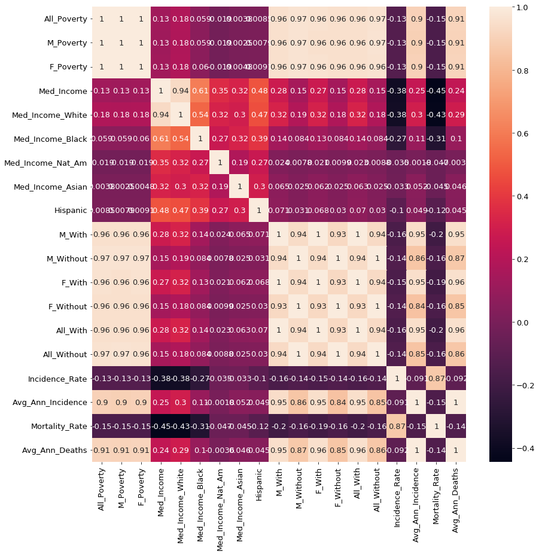

```python
plt.figure(figsize = (14, 14))
sns.heatmap(numerical_df.corr(), annot = True)
```

Our objective is to see the impact of the following two factors on cancer incidence and mortality:

- Economic status
- Social status

We first focus on the first task, i.e., to see how economic status may be related to cancer incidence and mortality.

From the available dataset, we make the following observations:

- The variables we have with respect to the economic status are the following:
  - Number of individuals below poverty line
  - Median income of individuals
- We expect a positive correlation between incidence/mortality rate and poverty rate, whereas we expect a negative correlation between median income and incidence/mortality rate.

Before, we set out to compute the relationships, it is important to understand the difference between the features Incidence_Rate and Avg_Ann_Incidence and between Mortality_Rate and Avg_Ann_Deaths.

Avg_Ann quantites represent **the numbers for the entire population** , whereas Incidence_Rate and Mortality_Rate represent **the numbers normalized using the total population** .

Since what is of relevance to us is the per capita rate, **we shall be considering only Incidence_Rate and Mortality_Rate** .

The important fact to note here is that All_Poverty is the total number of individuals below the poverty line, i.e. **it has not been normalized with total population,** whereas Incidence_Rate is already normalized. Hence, it is neccessary to normalize this quantity as well with respect to total population.

We can approximate the total population as the sum of all people with health insurance and all people without health insurance. We also calculate male and female population separately(to be used later):

```python
df.insert(loc = 0, column = 'All_Population', value = df['All_With'] + df['All_Without'])
df.insert(loc = 1, column = 'M_Population', value = df['M_With'] + df['M_Without'])
df.insert(loc = 2, column = 'F_Population', value = df['F_With'] + df['F_Without'])
```

Calculating the poverty rate per 100000 individuals:

```python
df.insert(loc = 3, column = 'All_Poverty_Rate', value = df['All_Poverty']*100000/df['All_Population'])
df.insert(loc = 4, column = 'M_Poverty_Rate', value = df['M_Poverty']*100000/df['M_Population'])
df.insert(loc = 5, column = 'F_Poverty_Rate', value = df['F_Poverty']*100000/df['F_Population'])
```

Removing absolute values since they are not of relevance:

```python
df.drop(['All_Poverty', 'M_Poverty', 'F_Poverty'], axis = 1, inplace = True)
```

Now let us compute the correlation again:

```python
df['All_Poverty_Rate'].corr(df['Incidence_Rate'])
```

```
0.32655282122113316
```

We see a significant positive correlation just like we expected! Let us visualize this through a plot:

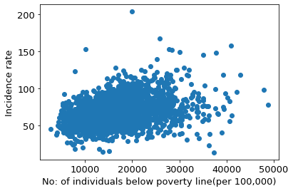

```python
plt.scatter(df['All_Poverty_Rate'], df['Incidence_Rate'])
plt.xlabel("No: of individuals below poverty line(per 100,000)")
plt.ylabel("Incidence rate")
plt.savefig("inc_pov.png")
```

We see a general positive correlation in the plot as well.

We repeat for Mortality_Rate:

```python
df['All_Poverty_Rate'].corr(df['Mortality_Rate'])
```

```
0.383232743132219
```

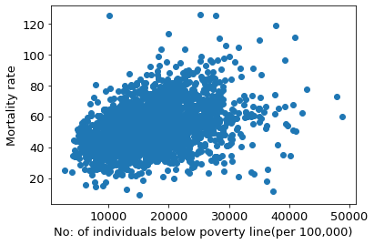

```python
plt.scatter(df['All_Poverty_Rate'], df['Mortality_Rate'])
plt.xlabel("No: of individuals below poverty line(per 100,000)")
plt.ylabel("Mortality rate")
plt.savefig("mor_pov.png")
```

We see a general positive correlation here as well.

Next, we examine Median Income feature.

```python
df['Med_Income'].corr(df['Incidence_Rate'])
```

```
-0.3798052589148917
```

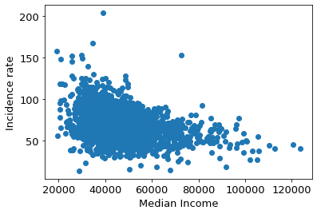

```python
plt.scatter(df['Med_Income'], df['Incidence_Rate'])
plt.xlabel("Median Income")
plt.ylabel("Incidence rate")
plt.savefig("inc_med.png")
```

```python
df['Med_Income'].corr(df['Mortality_Rate'])
```

```
-0.4452826102906732
```

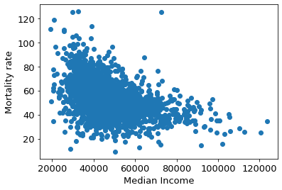

```python
plt.scatter(df['Med_Income'], df['Mortality_Rate'])
plt.xlabel("Median Income")
plt.ylabel("Mortality rate")
plt.savefig("mor_med.png")
```

**From the correlation values and plots, it can be qualitatively concluded that as poverty increases/ income decreases, there is a higher chance for cancer incidence/mortality in general.**

Let us also explore the effect of having health insurance on our target parameters. For this, like in the previous case it is necessary to compute the per capita values:

```python
df.insert(loc = 12, column = 'All_Insurance_Rate', value = df['All_With']/df['All_Population'])
df.insert(loc = 13, column = 'M_Insurance_Rate', value = df['M_With']/df['M_Population'])
df.insert(loc = 14, column = 'F_Insurance_Rate', value = df['F_With']/df['F_Population'])
```

```python
df.columns
```

```
Index(['All_Population', 'M_Population', 'F_Population', 'All_Poverty_Rate',
       'M_Poverty_Rate', 'F_Poverty_Rate', 'Med_Income', 'Med_Income_White',
       'Med_Income_Black', 'Med_Income_Nat_Am', 'Med_Income_Asian', 'Hispanic',
       'All_Insurance_Rate', 'M_Insurance_Rate', 'F_Insurance_Rate', 'M_With',
       'M_Without', 'F_With', 'F_Without', 'All_With', 'All_Without',
       'Incidence_Rate', 'Avg_Ann_Incidence', 'recent_trend', 'Mortality_Rate',
       'Avg_Ann_Deaths'],
      dtype='object')
```

```python
df['All_Insurance_Rate']
```

```
0       0.743959
1       0.868101
2       0.854663
3       0.787795
4       0.812350
          ...
2635    0.865122
2636    0.831483
2637    0.859531
2638    0.830681
2639    0.886759
Name: All_Insurance_Rate, Length: 2640, dtype: float64
```

```python
df['All_Insurance_Rate'].corr(df['Incidence_Rate'])
```

```
-0.03851140101570041
```

It seems like there isn't any correlation at all between cancer incidence and having a health insurance. This is to be expected because a health insurance is of use only in the treatment of a disease; not so much for its prevention.

```python
df['All_Insurance_Rate'].corr(df['Mortality_Rate'])
```

```
-0.12415643020283608
```

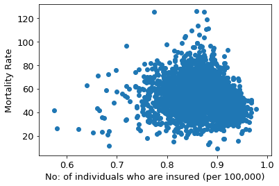

```python
plt.scatter(df['All_Insurance_Rate'], df['Mortality_Rate'])
plt.xlabel("No: of individuals who are insured (per 100,000)")
plt.ylabel("Mortality Rate")
plt.savefig("ins_mort.png")
```

Next, out target is to associate social status with cancer incidence/ mortality.

Towards this, we shall consider the following two broad social classification criterion:

- Gender
- Ethnicity

The major challenge we face is that we **do not have direct access to incidence/mortality rate for each section separately.** For instance, we do not know the separate count of male individuals having cancer incidence and female individuals having cancer incidence. This prohibits any direct comparison.

As a result, it is necessary to make an **indirect comparison** based on the available parameters.

We first consider gender. With respect to gender we have the following available parameters:

- Poverty rate for males and females separately
- Rate of individuals having life insurance for males and females separately

Since we have already conculed from earlier analysis that poverty rate has a positive correlation with both incidence rate and mortality rate, if we can conclude that one section has a higher poverty rate in general, we can conclude that this section suffers from higher incidence/mortality as well.

Let us make box plots for the two sections:

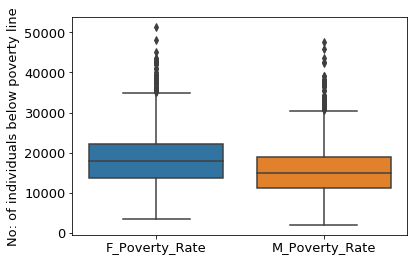

```python
sns.boxplot(data = df[["F_Poverty_Rate", "M_Poverty_Rate"]])
plt.ylabel("No: of individuals below poverty line")
plt.savefig("box_pov.png")
```

From the plot, it seems that the **poverty rate is higher for the female population**, atleast qualitatively. To see this quantitatively, consider:

```python
df[["F_Poverty_Rate", "M_Poverty_Rate"]].describe()
```

|  | F_Poverty_Rate | M_Poverty_Rate |
| --- | --- | --- |
| count | 2640.000000 | 2640.000000 |
| mean | 18438.267600 | 15449.460381 |
| std | 6671.494646 | 6015.827048 |
| min | 3422.382671 | 1972.637607 |
| 25% | 13757.330077 | 11153.223760 |
| 50% | 17891.631556 | 14869.535936 |
| 75% | 22205.200648 | 18859.267008 |
| max | 51264.842540 | 47576.177285 |

As can be seen, both **mean and median poverty rate is higher for the female population.** Hence, from this, it can be concluded that female population in general has higher poverty rate and consequently **higher values for cancer incidence and mortality rate.**

For health insurance:

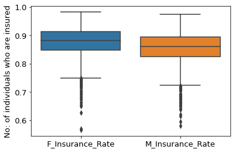

```python
sns.boxplot(data = df[["F_Insurance_Rate", "M_Insurance_Rate"]])
plt.ylabel("No: of individuals who are insured")
plt.savefig("box_ins.png")
```

Next, we explore the relationship between ethnicity and cancer incidence/mortality.

In this case, the parameter available to us in median income. As we have seen before, a lower medican income would correspond to higher cancer incidence/mortality.

Let us see how the median incomes for different ethnic sections are distributed:

```python
ethnic_cols = ['Med_Income','Med_Income_White', 'Med_Income_Black', 'Med_Income_Nat_Am', 'Med_Income_Asian', 'Hispanic']
```

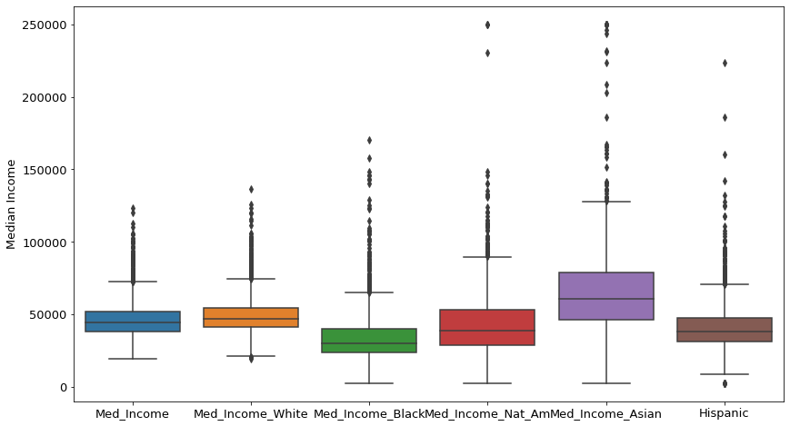

```python
plt.figure(figsize = (14, 8))
sns.boxplot(data = df[ethnic_cols])
plt.ylabel("Median Income")
plt.savefig('box_ethnic.png')
```

It can be seen that the median income of different sections are different, with some sections having higher values and others having lower.

Quantitavely:

```python
df[ethnic_cols].describe()
```

|  | Med_Income | Med_Income_White | Med_Income_Black | Med_Income_Nat_Am | Med_Income_Asian | Hispanic |
| --- | --- | --- | --- | --- | --- | --- |
| count | 2640.000000 | 2640.000000 | 1818.000000 | 1295.000000 | 1278.000000 | 2127.000000 |
| mean | 46542.398485 | 49386.191667 | 34708.625413 | 43468.138224 | 65998.231612 | 41039.206394 |
| std | 12529.141437 | 12713.167597 | 18087.803105 | 24197.024884 | 34411.305663 | 16272.038982 |
| min | 19328.000000 | 19340.000000 | 2499.000000 | 2499.000000 | 2499.000000 | 2499.000000 |
| 25% | 38226.250000 | 41175.250000 | 23835.000000 | 28969.000000 | 46340.500000 | 31591.500000 |
| 50% | 44497.000000 | 47043.500000 | 29983.500000 | 39028.000000 | 60516.000000 | 38198.000000 |
| 75% | 51993.250000 | 54484.750000 | 40337.250000 | 53190.500000 | 79002.000000 | 47282.500000 |
| max | 123453.000000 | 136311.000000 | 170195.000000 | 250001.000000 | 250001.000000 | 223750.000000 |

It can be seen that both the mean and median of the median income follow the following order for ethnic groups:

**Asians > Whites > Native Americans > Hispanics > Blacks**

From our previous discussion, it is reasonable to assume that the incidence rate/mortality rate might also vary accordingly.

**Incidence v/s Mortality**

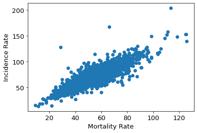

```python
plt.scatter(df['Mortality_Rate'], df['Incidence_Rate'])
plt.xlabel("Mortality Rate")
plt.ylabel("Incidence Rate")
plt.savefig('inc_mort.png')
```

```python
df[['Mortality_Rate', 'Incidence_Rate']].corr()
```

|  | Mortality_Rate | Incidence_Rate |
| --- | --- | --- |
| Mortality_Rate | 1.000000 | 0.866983 |
| Incidence_Rate | 0.866983 | 1.000000 |

### Applying Linear Regression

To formally validate the observations we made during EDA, we apply linear regression.

**Model 1: Using only poverty rate**

We train a linear regression model which uses only poverty rate to predict the incidence/mortality rate. The error of this model can then be used as an indicator of how good of a predictor the poverty rate is.

```python
arr_poverty = np.array(df['All_Poverty_Rate'])
arr_incidence = np.array(df['Incidence_Rate'])

poverty_reg = LinearRegression().fit(arr_poverty.reshape(-1, 1), arr_incidence)
poverty_predictions = poverty_reg.predict(arr_poverty.reshape(-1, 1))
```

```python
poverty_reg.coef_
```

```
array([0.00092112])
```

```python
arr_incidence.shape
```

```
(2640,)
```

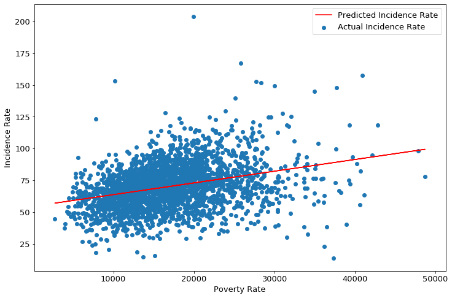

```python
plt.figure(figsize = (12,8))
plt.plot(arr_poverty, poverty_predictions.reshape(-1), 'r', label = "Predicted Incidence Rate")
plt.scatter(arr_poverty, arr_incidence, label = "Actual Incidence Rate")
plt.xlabel('Poverty Rate')
plt.ylabel('Incidence Rate')
plt.legend()
plt.savefig("m1_inc.png")
```

```python
mse = mean_squared_error(poverty_predictions, arr_incidence)
mse
```

```
279.3972894574652
```

```python
poverty_r2 = r2_score(arr_incidence, poverty_predictions)
poverty_r2
```

```
0.10663674504748122
```

```python
arr_poverty = np.array(df['All_Poverty_Rate'])
arr_mortality = np.array(df['Mortality_Rate'])

poverty_mor_reg = LinearRegression().fit(arr_poverty.reshape(-1, 1), arr_mortality)
poverty_mor_predictions = poverty_mor_reg.predict(arr_poverty.reshape(-1, 1))
```

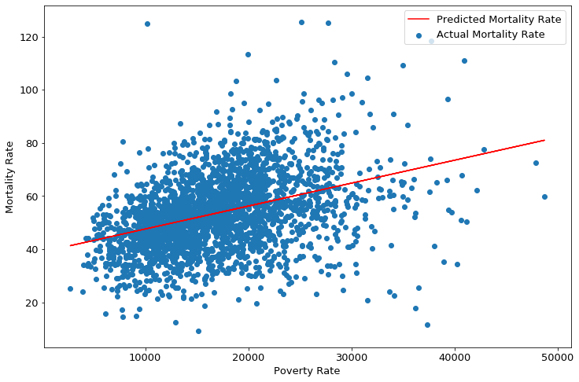

```python
plt.figure(figsize = (12,8))
plt.plot(arr_poverty, poverty_mor_predictions.reshape(-1), 'r', label = "Predicted Mortality Rate")
plt.scatter(arr_poverty, arr_mortality, label = "Actual Mortality Rate")
plt.xlabel('Poverty Rate')
plt.ylabel('Mortality Rate')
plt.legend(loc = 'upper right')
plt.savefig("m1_mor.png")
```

```python
mse_pov_mor = mean_squared_error(poverty_mor_predictions, arr_mortality)
print(mse_pov_mor)
poverty_mor_r2 = r2_score(arr_mortality, poverty_mor_predictions)
print(poverty_mor_r2)
```

```
169.96783516143543
0.14686733540864527
```

**Model 2: Using only median income**

```python
arr_income = np.array(df['Med_Income'])

income_reg = LinearRegression().fit(arr_income.reshape(-1, 1), arr_incidence)
income_predictions = income_reg.predict(arr_income.reshape(-1, 1))
```

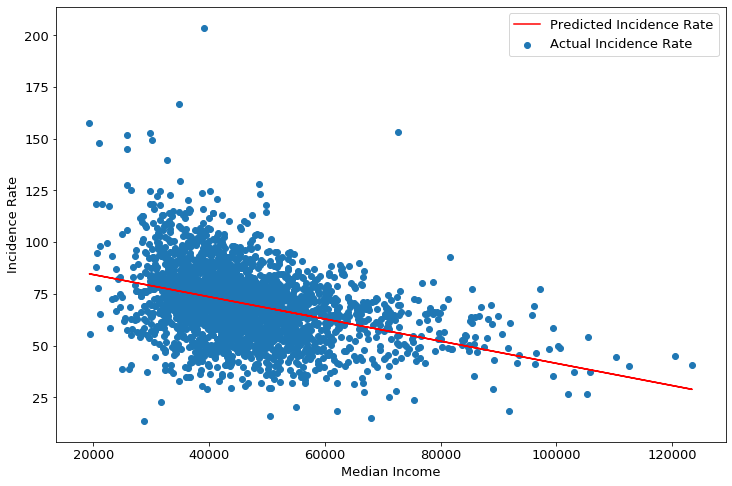

```python
plt.figure(figsize = (12,8))
plt.plot(arr_income, income_predictions, 'r', label = "Predicted Incidence Rate")
plt.scatter(arr_income, arr_incidence, label = "Actual Incidence Rate")
plt.xlabel("Median Income")
plt.ylabel("Incidence Rate")
plt.legend()
plt.savefig("m2_inc.png")
```

```python
income_mse = mean_squared_error(income_predictions, arr_incidence)
income_mse
```

```
267.633194714768
```

```python
income_r2 = r2_score(arr_incidence, income_predictions)
income_r2
```

```
0.14425203469940784
```

```python
arr_income = np.array(df['Med_Income'])

income_mor_reg = LinearRegression().fit(arr_income.reshape(-1, 1), arr_mortality)
income_mor_predictions = income_mor_reg.predict(arr_income.reshape(-1, 1))
```

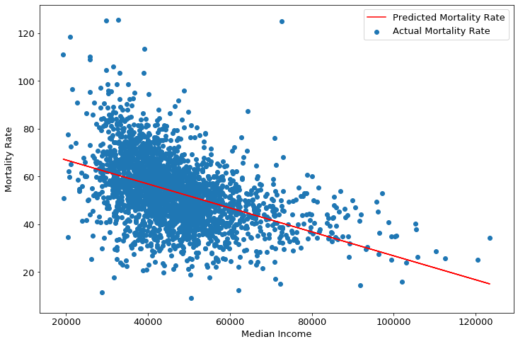

```python
plt.figure(figsize = (12,8))
plt.plot(arr_income, income_mor_predictions, 'r', label = "Predicted Mortality Rate")
plt.scatter(arr_income, arr_mortality, label = "Actual Mortality Rate")
plt.xlabel("Median Income")
plt.ylabel("Mortality Rate")
plt.legend()
plt.savefig("m2_mor.png")
```

```python
mse_inc_mor = mean_squared_error(income_mor_predictions, arr_mortality)
print(mse_inc_mor)
inc_mor_r2 = r2_score(arr_mortality, income_mor_predictions)
print(inc_mor_r2)
```

```
159.72567437327845
0.19827660302727546
```

**Model 3: Using both poverty rate and median income**

```python
arr_joint = np.array(df[['All_Poverty_Rate', 'Med_Income']])

joint_reg = LinearRegression().fit(arr_joint, arr_incidence.reshape(-1, 1))
joint_predictions = joint_reg.predict(arr_joint)
```

```python
arr_joint.shape
```

```
(2640, 2)
```

```python
arr_incidence.shape
```

```
(2640,)
```

```python
len(joint_predictions)
```

```
2640
```

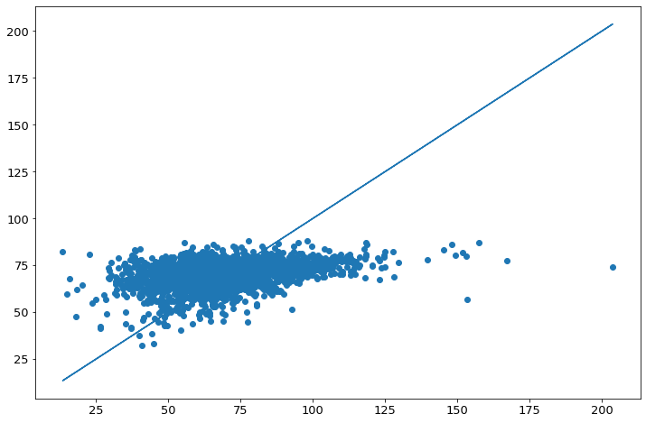

```python
plt.figure(figsize = (12,8))
plt.scatter(arr_incidence, joint_predictions)
plt.plot(arr_incidence, arr_incidence)
```

```python
joint_mse = mean_squared_error(joint_predictions, arr_incidence)
joint_mse
```

```
267.03215420282834
```

```python
joint_r2 = r2_score(arr_incidence, joint_predictions)
joint_r2
```

```
0.14617384113191623
```

```python
arr_joint = np.array(df[['All_Poverty_Rate', 'Med_Income']])

joint_mor_reg = LinearRegression().fit(arr_joint, arr_mortality.reshape(-1, 1))
joint_mor_predictions = joint_mor_reg.predict(arr_joint)
```

```python
joint_mor_mse = mean_squared_error(joint_mor_predictions, arr_mortality)
print(joint_mor_mse)

joint_mor_r2 = r2_score(arr_mortality, joint_mor_predictions)
print(joint_mor_r2)
```

```
159.1865591066743
0.20098262586673232
```

```python
from sklearn.preprocessing import PolynomialFeatures
```

```python
poly = PolynomialFeatures(6)
new_feat = poly.fit_transform(arr_joint)
```

```python
poly_reg = LinearRegression().fit(new_feat, arr_incidence.reshape(-1, 1))
poly_predictions = poly_reg.predict(new_feat)
```

```python
poly_mse = mean_squared_error(poly_predictions, arr_incidence)
poly_mse
```

```
249.67449718230483
```

```python
poly_r2 = r2_score(arr_incidence, poly_predictions)
poly_r2
```

```
0.20167435441289794
```

```python
poly_mor_reg = LinearRegression().fit(new_feat, arr_mortality.reshape(-1, 1))
poly_mor_predictions = poly_mor_reg.predict(new_feat)
```

```python
poly_mor_mse = mean_squared_error(poly_mor_predictions, arr_mortality)
print(poly_mor_mse)
poly_mor_r2 = r2_score(arr_mortality, poly_mor_predictions)
print(poly_mor_r2)
```

```
146.29212012418955
0.2657046779955332
```